# Hackathon 5/Assignment 6

12/10/2020

# Instructions

## Task I

- You will be working in groups on a quantified student project
- Download the Sensor Kinetics Pro app to your iOS or Android device (or similar gyroscope measuring app)
- Split into subgroups with each subgroup investigating one measure available in the app
- Each subgroup should report back after 20min with what they have learned

## Task II

- In consultation with your group select a physical activity that: a) can be measured using the app, b) has a concrete, continuous, countable outcome and c) some members of the group are experts and some are novices at - If you are looking for inspiration you can find previous student projects below.
- Collect measurements for all members of the group performing the task using the app
- Create a Github repo where you can store and share your data
- Using K-means, can you identify the novices from the experts using only the app data?
- Visualize your results using ggplot2

```r
# In our activity we did not specify who are the novices and who are the experts
# Here is our methodology for this task: use K-means "using ONLY THE APP DATA" (as in the instruction)
# This means that only variables X_Value Y_Value and Z-Value will enter the K-means calculation
# From the results, we will see if the clusters have any correlation with #Jumps
# Hypothesis is that "experts" will have jumped more than "novices"

library(dplyr)
library(tidyr)
```

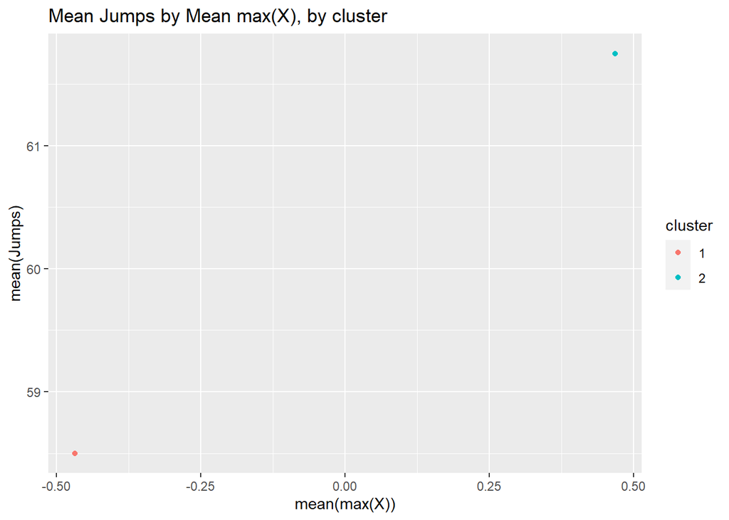

```r
library(ggplot2)
library(stringr)
DF <- read.csv("jump_datagroup.csv")
DF$ID <- c(1:8)
DF1 <- select(DF, 4:6)
DF2 <- data.frame(scale(DF1)) #scale data to be used in K-means

# K-means data frame
set.seed(7)
fit <- kmeans(DF2, 2) # 2 clusters: experts/novices
DF3 <- data.frame(DF2, fit$cluster)
DF3$cluster <- as.factor(fit$cluster)
DF3 <- DF3 %>% select(-fit.cluster)
DF3$jumps <- DF$jumps
DF3$id <- DF$ID
DF3$names <- DF$id

# Graph 1: See mean(#jumps) by cluster
# Cluster 2 (Dan, Daisy, Yen-Ling and Qianhui) jumped more on average than Cluster 1 (Amanda, Aniket, Junhao, Xinyuan)
# It is a strong conclusion (for the weak data we have), but Cluster 2 is for Experts and 1 for Novices
# The graphs below are generated for all X-Y-Z dimensions because it is hard to know if participants held their cellphones in a consistent manner
DF4 <- DF3 %>% group_by(cluster) %>% summarise(avgX = mean(X_value), avgY = mean(Y_value), avgZ = mean(Z_value), avgJ=mean(jumps))
ggplot(DF4, aes(avgX, avgJ, colour = cluster)) + geom_point() + xlab("mean(max(X))") + ylab("mean(Jumps)") + ggtitle("Mean Jumps by Mean max(X), by cluster")
```

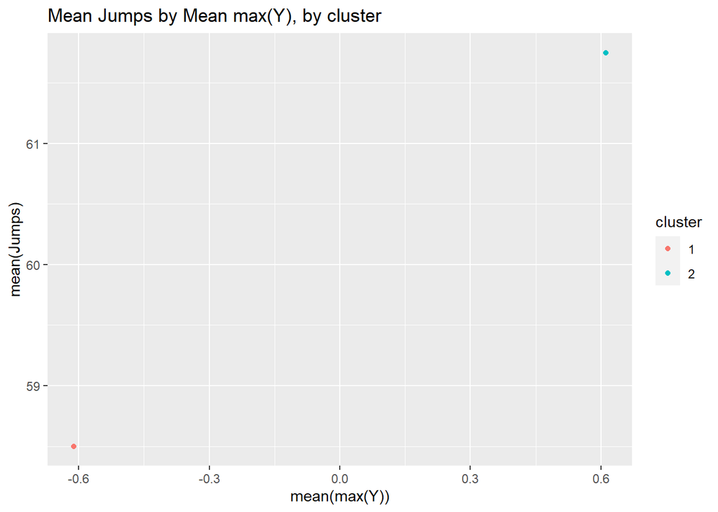

```r
ggplot(DF4, aes(avgY, avgJ, colour = cluster)) + geom_point() + xlab("mean(max(Y))") + ylab("mean(Jumps)") + ggtitle("Mean Jumps by Mean max(Y), by cluster")
```

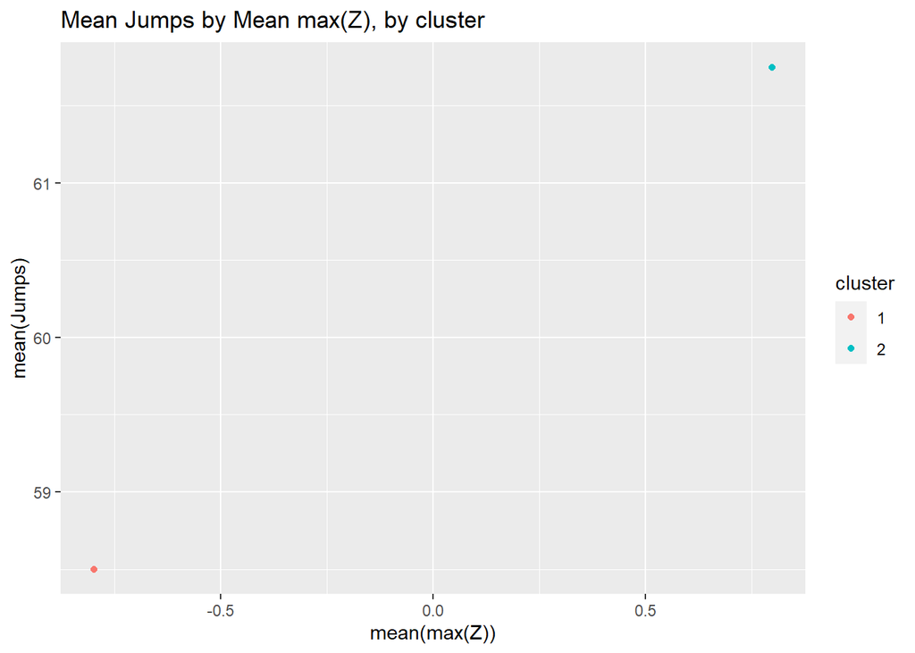

```r
ggplot(DF4, aes(avgZ, avgJ, colour = cluster)) + geom_point() + xlab("mean(max(Z))") + ylab("mean(Jumps)") + ggtitle("Mean Jumps by Mean max(Z), by cluster")
```

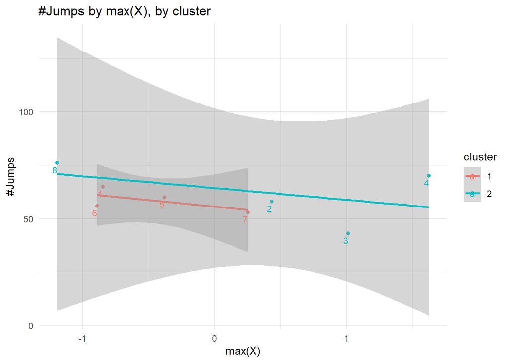

```r
# Graph 2: Don't average across clusters. See all data points in graph : Stick to X dimension this time
ggplot(DF3, aes(X_value, jumps, colour = cluster, label=id)) + geom_point() + xlab("max(X)") + ylab("#Jumps") + geom_smooth(method='lm',formula=y~x) + geom_text(aes(label=id),hjust=1, vjust=1.5, size=3) +  ggtitle("#Jumps by max(X), by cluster") + theme_minimal()
```

## Task III

- Devise five questions on a five point Likert scale that ask members of your group about their experience with your chosen task
- Collect data from all members of your group
- Run a PCA analysis on the data
- What does PC1 represent in your analysis?
- Visualize the PC1 results for each member of your group

```r
DFF <- select(DF, -c(1:6, 12))

set.seed(7)
pca <- prcomp(DFF, scale. = TRUE)
summary(pca)
```

```
## Importance of components:
##                           PC1    PC2    PC3    PC4     PC5
## Standard deviation     1.2843 1.2305 1.0911 0.7158 0.36543
## Proportion of Variance 0.3299 0.3028 0.2381 0.1025 0.02671
## Cumulative Proportion  0.3299 0.6328 0.8708 0.9733 1.00000
```

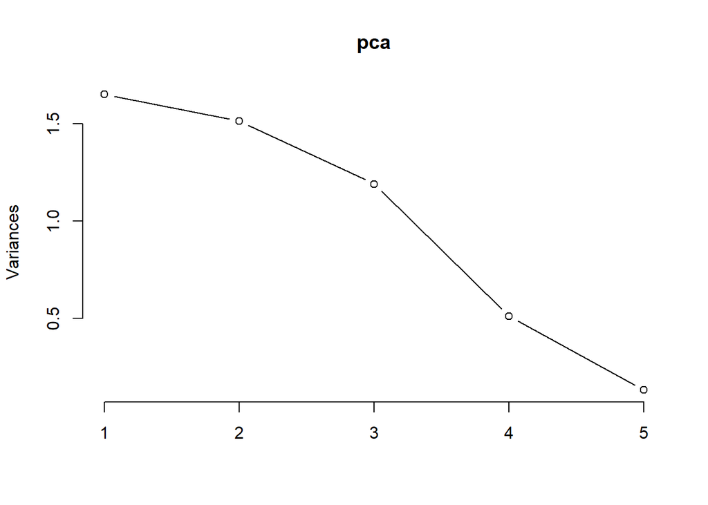

```r
plot(pca, type = "lines")
```

```r
pca$rotation
```

```
##             PC1         PC2        PC3        PC4        PC5
## Q1 -0.401875295 -0.63925516  0.1991508 -0.2022935  0.5909868
## Q2  0.008200607  0.62052441  0.4624060 -0.5358435  0.3375420
## Q3  0.596618705  0.01239717 -0.5531647 -0.0923447  0.5739109
## Q4 -0.457614817  0.07789220 -0.6213580 -0.5916189 -0.2200520
## Q5 -0.522555067  0.44730461 -0.2333296  0.5598291  0.3987524
```

```r
pca$x
```

```
##              PC1         PC2        PC3        PC4         PC5
## [1,]  0.08748844  2.45361467  0.6626958  0.2910554  0.05018931
## [2,]  0.31523189 -1.70668693  0.2613330  0.1930801 -0.49931631
## [3,]  0.98410716  0.84081494 -1.0441278  0.1973222 -0.54154629
## [4,] -0.90642368 -0.03856156  1.5268155 -0.1334046 -0.06388029
## [5,] -0.81361607 -0.74039852 -0.2427166  1.4024491  0.36208732
## [6,]  0.33107697 -0.50771987  1.1547864 -0.8422680  0.15287670
## [7,] -2.10584093  0.08038758 -1.5613544 -0.7960966  0.06298551
## [8,]  2.10797622 -0.38145032 -0.7574320 -0.3121375  0.47660404
```

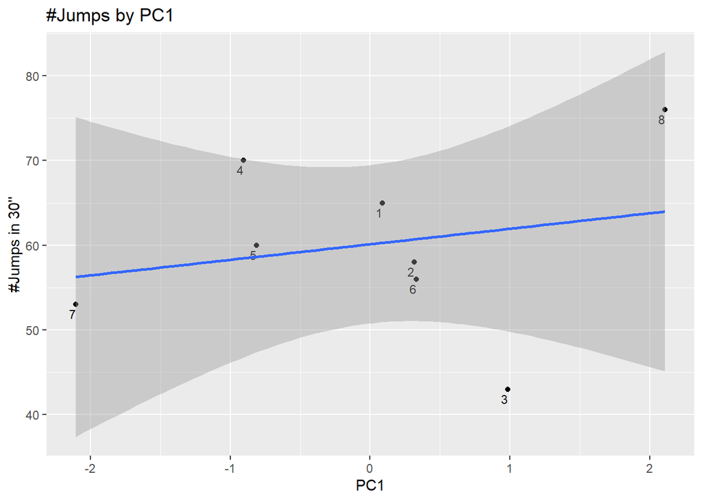

```r
# Inspect loadings
DFF2 <- as.data.frame(pca$rotation)

    # PC1: -Q1, -Q4, -Q5, +Q3. It is hard to understand what it represents exactly. >PC1, >Jumps?
    # Q1    I consider myself a great jumper
    # Q2    How often do you exercise?
    # Q3    Did you feel tired after jumping for 30 seconds?
    # Q4    Do you have any health condition that makes jumping difficult?
    # Q5    I consider exercising a joyful activity

#What does PC1 represent in our analysis
#We think that PC1 stands for physical fitness and member's interest in jumping because PC1 has a strong negative loading for Q5 and  positive loading for Q3. These questions are more about the opinions and physical state of the group members. And Q3 is about members' energy after the jumping while Q5 is more related to the interest. If one has higher scores in Q5, he/she might get lower scores for PC1

#PLOT
jumpPC <- as.data.frame(pca$x)
jumpPC$jump <- DF$jumps
jumpPC$id <- DF$ID

ggplot(jumpPC, aes(PC1, jump, label=id)) + geom_point() + xlab("PC1") + ylab("#Jumps in 30''") + geom_text(aes(label=id),hjust=1, vjust=1.5, size=3)+ geom_smooth(method='lm',formula=y~x) + ggtitle("#Jumps by PC1")
```